# Homework MP1

2024-10-19

```r
library(readxl)
library(forecast)
```

```r
library(tseries)
library(TTR)
library(ggplot2)
library(tidyr)
library(dplyr)
flightVolume <- read.csv("/Users/kiannazem/Downloads/flightVolume.csv")
```

```r
flight_ts <- ts(flightVolume$reslong, start = c(1971, 01), frequency = 12)
```

```r
str(flight_ts)
```

```
##  Time-Series [1:498] from 1971 to 2012: 7.39 5.13 6.35 5.64 6.73 5.17 5.56 6 4.49 4.22 ...
```

```r
start(flight_ts)
```

```
## [1] 1971    1
```

```r
end(flight_ts)
```

```
## [1] 2012    6
```

```r
length(flight_ts)
```

```
## [1] 498
```

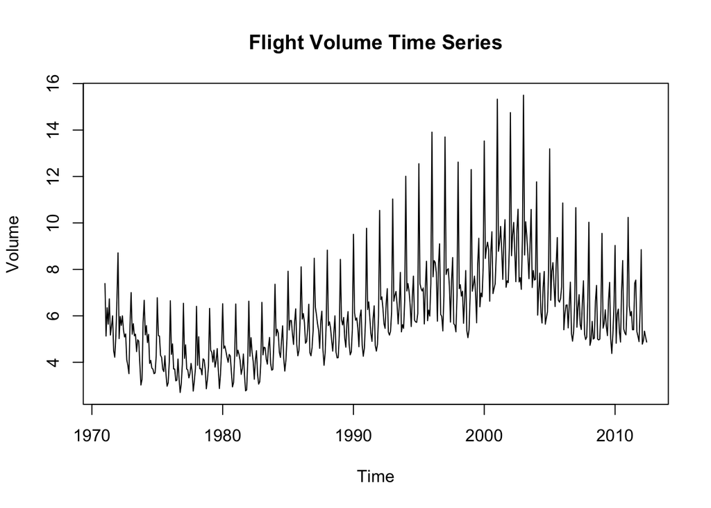

```r
plot(flight_ts, main="Flight Volume Time Series", ylab="Volume", xlab="Time")
```

Hypothesis: Flight volume data likely has an underlying trend, as flights may increase or decrease over time depending on economic factors, policy changes, and global events. Also, it is very likely that the flight volume data has seasonality, as certain months like holiday seasons might have more flights than others. I hypothesize that the data will have both a trend and seasonal fluctuations.

```r
start(flight_ts)
```

```
## [1] 1971    1
```

```r
end(flight_ts)
```

```
## [1] 2012    6
```

```r
length(flight_ts)
```

```
## [1] 498
```

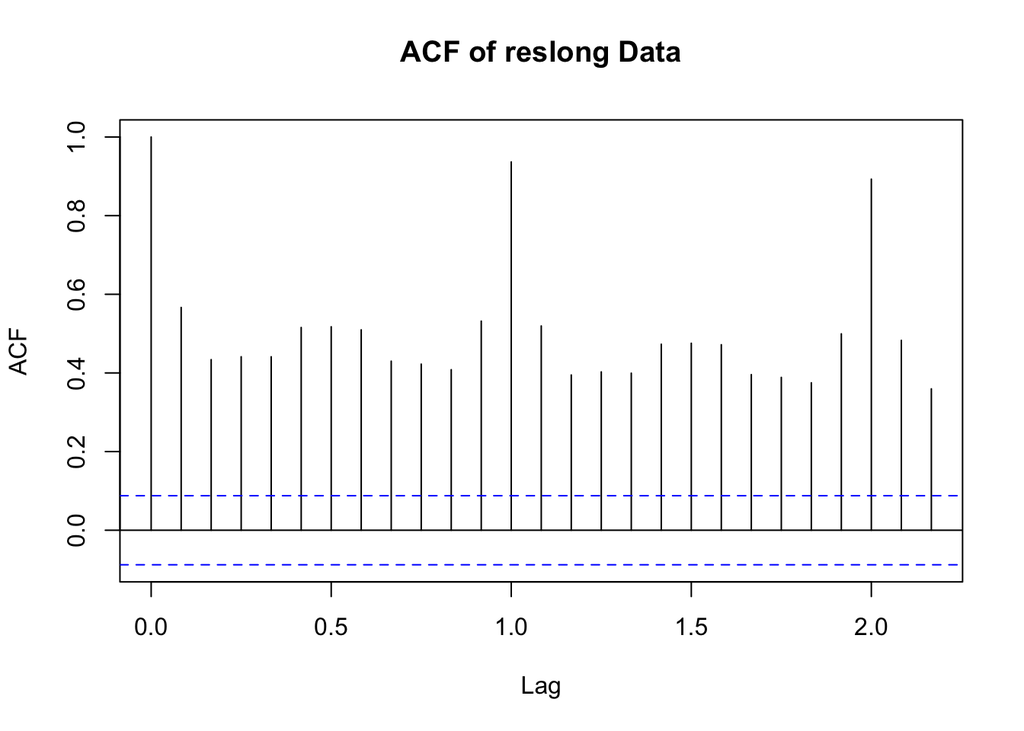

```r
acf(flight_ts, main="ACF of reslong Data")
```

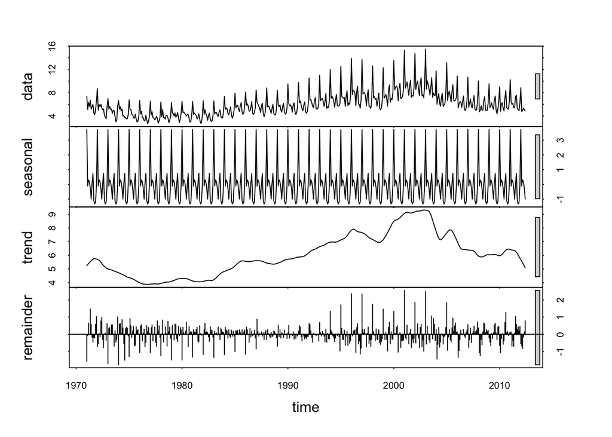

```r
decomp_result <- stl(flight_ts, s.window = "periodic")
plot(decomp_result)
```

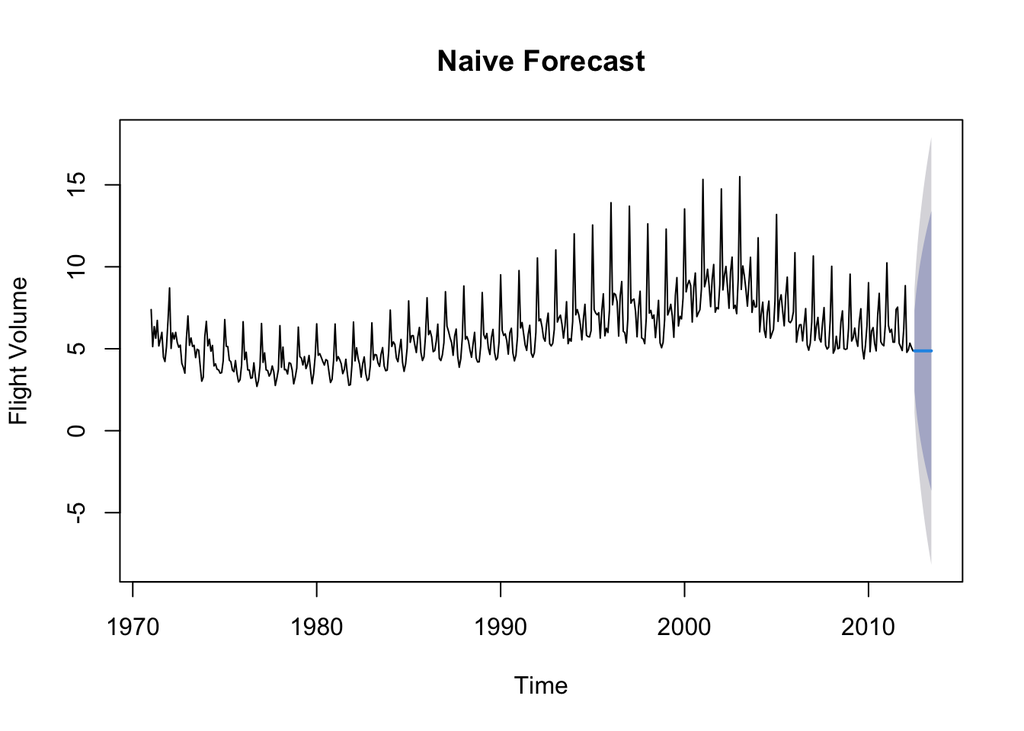

```r
naive_forecast <- naive(flight_ts, h=12)
plot(naive_forecast, main="Naive Forecast", ylab="Flight Volume", xlab="Time")
```

The Naive forecast assumes that the future will be exactly like the most recent past so it projects the last observed value straight into the future without accounting for trends or seasonality. This results in a flat line, with confidence intervals that widen to account for uncertainty. This doesn’t seem suitable for my dataset since it ignores important seasonal patterns and trends.

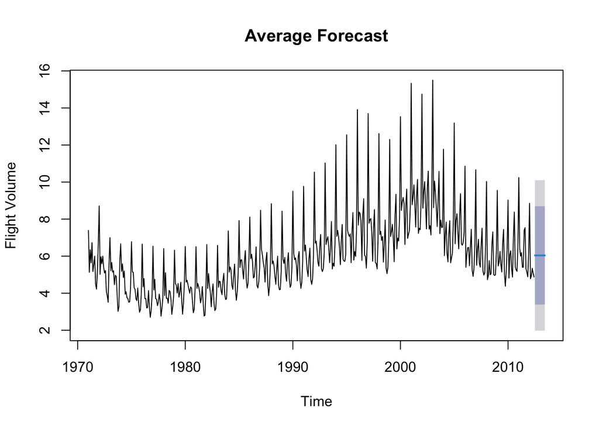

```r
average_forecast <- meanf(flight_ts, h=12)
plot(average_forecast, main="Average Forecast", ylab="Flight Volume", xlab="Time")
```

The average forecast assumes that future flight volumes will remain the same as the historical average. It doesn’t account for any trend or seasonality, so it gives a flat prediction line once again. The blue shaded area shows possible deviations from the average. This model doesn’t seem to capture the real nature of the data, since it ignores the seasonal fluctuations and the longer-term trend.

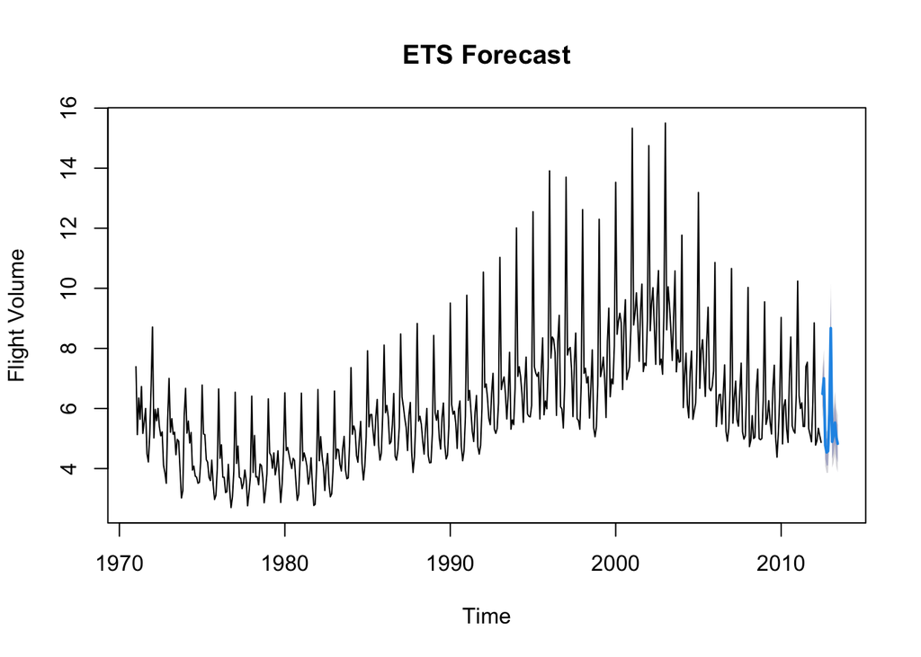

```r
ets_model <- ets(flight_ts)
ets_forecast <- forecast(ets_model, h=12)
plot(ets_forecast, main="ETS Forecast", ylab="Flight Volume", xlab="Time")
```

The exponential smoothing forecast incorporates both trend and seasonality, but it’s more adaptable to changes in these patterns. Like the Holt-Winters model, the ETS forecast shows that future volumes are expected to follow the same seasonal patterns. The confidence intervals are represented by the blue shaded area, giving an idea of the uncertainty in the predictions.

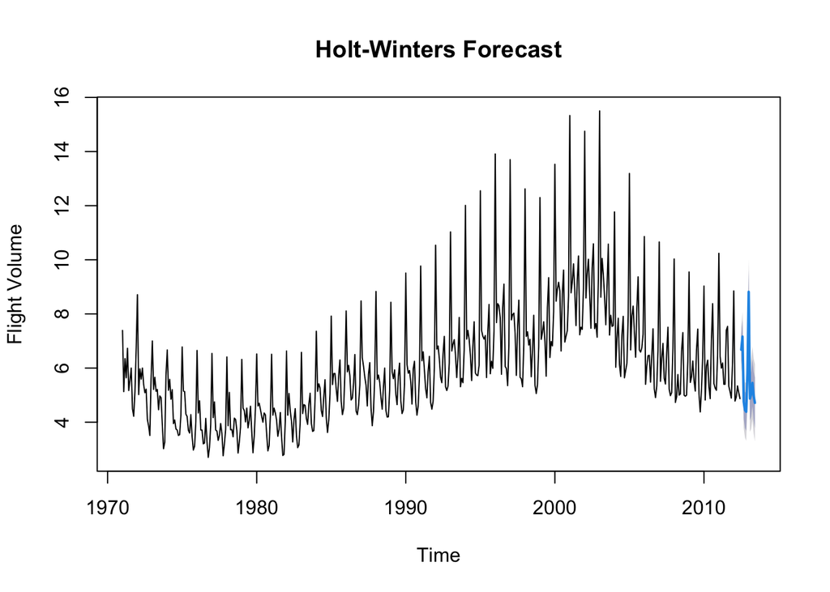

```r
hw_forecast <- HoltWinters(flight_ts)
plot(forecast(hw_forecast, h=12), main="Holt-Winters Forecast", ylab="Flight Volume", xlab="Time")
```

The Holt-Winters forecast accounts for both the trend and seasonality. The model shows that flight volumes are expected to continue fluctuating with the same seasonal patterns, but there’s not really a clear trend. The blue shaded area shows the confidence intervals which tells us that the range within which future flight volumes are expected to fall.

```r
additive_decomp <- decompose(flight_ts, type = "additive")
multiplicative_decomp <- decompose(flight_ts, type = "multiplicative")
```

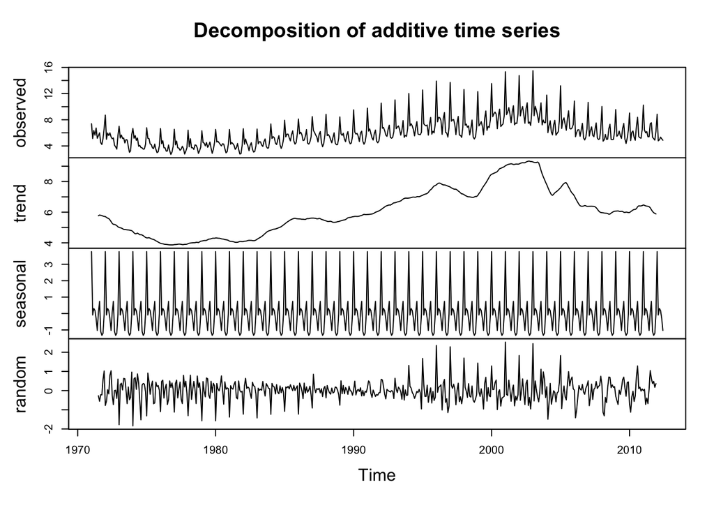

```r
plot(additive_decomp)
```

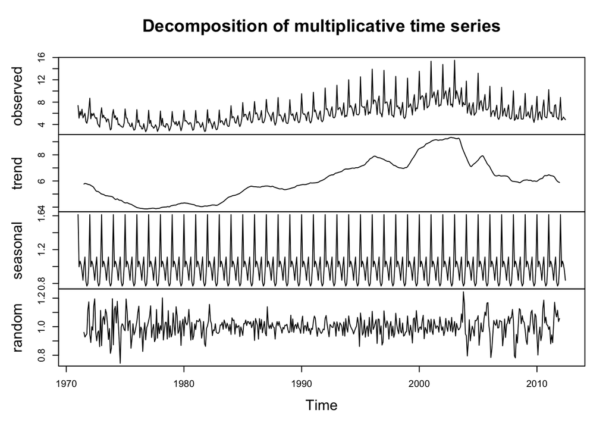

```r
plot(multiplicative_decomp)
```

```r
accuracy_naive <- accuracy(naive_forecast)
accuracy_avg <- accuracy(average_forecast)
accuracy_ets <- accuracy(ets_forecast)
accuracy_hw <- accuracy(forecast(hw_forecast))

print("Naive Forecast Accuracy:")
```

```
## [1] "Naive Forecast Accuracy:"
```

```r
print(accuracy_naive)
```

```
##                        ME     RMSE     MAE       MPE     MAPE     MASE
## Training set -0.005070423 1.921782 1.27839 -3.431347 19.95608 2.617313
##                    ACF1
## Training set -0.3457839
```

```r
print("Average Forecast Accuracy:")
```

```
## [1] "Average Forecast Accuracy:"
```

```r
print(accuracy_avg)
```

```
##                        ME    RMSE      MAE       MPE     MAPE     MASE
## Training set 3.598537e-16 2.06368 1.549925 -10.72472 27.71948 3.173239
##                   ACF1
## Training set 0.5665141
```

```r
print("ETS Forecast Accuracy:")
```

```
## [1] "ETS Forecast Accuracy:"
```

```r
print(accuracy_ets)
```

```
##                       ME      RMSE       MAE        MPE     MAPE      MASE
## Training set -0.00832737 0.4181118 0.2994809 -0.3984877 5.068336 0.6131423
##                   ACF1
## Training set 0.2333164
```

```r
print("Holt-Winters Forecast Accuracy:")
```

```
## [1] "Holt-Winters Forecast Accuracy:"
```

```r
print(accuracy_hw)
```

```
##                      ME      RMSE       MAE        MPE     MAPE      MASE
## Training set 0.01041486 0.4260906 0.3082114 0.09657761 5.211693 0.6310167
##                   ACF1
## Training set 0.1020312
```

The exponential smoothing model is the most accurate based on RMSE, MAE, and MAPE. I would use this model for forecasting as it captures both trend and seasonality effectively. The Holt-Winters model is also a strong contender, especially to emphasize the seasonality. It’s slightly less accurate than ETS but still performs well. In this particular case, I will go with the exponential smoothing model as my forecast, given the accuracy measure above.

```r
forecast(ets_forecast, h=12)
```

```
##          Point Forecast    Lo 80    Hi 80    Lo 95     Hi 95
## Jul 2012       6.485343 5.932740 7.037947 5.640209  7.330477
## Aug 2012       7.001619 6.372579 7.630659 6.039586  7.963652
## Sep 2012       4.775558 4.325071 5.226044 4.086598  5.464518
## Oct 2012       4.539004 4.091084 4.986923 3.853970  5.224038
## Nov 2012       4.579383 4.108164 5.050603 3.858716  5.300051
## Dec 2012       5.823284 5.200240 6.446328 4.870420  6.776148
## Jan 2013       8.672300 7.709983 9.634617 7.200563 10.144037
## Feb 2013       4.891801 4.330102 5.453501 4.032756  5.750847
## Mar 2013       5.111501 4.505382 5.717620 4.184522  6.038480
## Apr 2013       5.526846 4.851273 6.202419 4.493646  6.560046
## May 2013       5.041074 4.406922 5.675226 4.071223  6.010926
## Jun 2013       4.827553 4.203488 5.451618 3.873128  5.781978
```

I feel confident in the Exponential Smoothing forecast because it effectively captures both the trend and seasonality in my flight volume data. The model adapts to recent changes in the data, giving more weight to recent patterns, which is crucial in an industry that can experience fluctuations. It also performed best in terms of accuracy, with the lowest RMSE and MAE, indicating it provides the most reliable predictions. Additionally, the forecast includes confidence intervals, giving me a range of likely outcomes, which further strengthens my confidence in its predictions.